# 데이터 과학 – 기초 통계

A/B 검정 – A안 혹은 B안 선정

## 학습 목표

> - A/B 검정을 통해 사용자 선호도를 통계검정을 통해 수행한다.
> - 단일 표본 비율 검정을 이해한다.
> - 단일 표본 수준이 3개 이상인 경우 비율 검정을 수행한다.

## 1. A/B 검정 통계량

A/B 검정에 많이 사용되는 검정 통계량은 다양하다. 이유는 실무에서 풀고자하는 문제가 달라 활용되는 사례가 다르기 때문이다. [^1]

| 가정한 분포 | 활용 사례 | 검정 통계량 | 추가 검토 검정 통계량 |
| --- | --- | --- | --- |
| 정규분포 | 과금 유져당 평균 과금액 | 웰치 $t-$검정 | 스튜던트 $t-$검정 |
| 이항분포 | CTR(클릭율) | 피셔 정확검정 | Barnard 검정 |
| 포아송분포 | 과금유저당 평균 거래횟수 | E-검정 | C-검정 |
| 다항분포 | 각 제품별 구매횟수 | $\chi^2$ 검정 | — |
| 분포가정 없음 | – | 맨휘트니 U 검정 | 깁스 표집 |

### 1.1. 검정력(Power) [^2]

검정력(Power)은 실험계획법에서 특히 중요하다. 실험에 대한 효과를 측정하기 위해서는 표본크기를 설정해야 하는데 무한정 크게하면 비용에 대한 제약이 있고, 수월하게 진행하기 위해서 표본크기를 너무 작게하면 주어진 신뢰수준에서 효과크기를 잡아내기 어렵다. 달리 말하면, 표본크기가 주어지게 되면 미리 설정한 신뢰수준에서 효과크기를 측정할 수 있게 해 준다. 검정력을 포함하여 총 5가지 변수가 서로 밀접한 관계를 갖는다.

1. 표본크기
2. 효과크기(Effect Size)
3. 유의수준(1종 오류 확률): 존재하지 않는 효과를 찾아낼 확률
4. 검정력(1 - 2종 오류 확률): 존재하는 효과를 찾아낼 확률
5. 대립가설: 양측검정 등

`pwr` 팩키지는 코헨(Cohen, 1988)이 기술한 검정력분석을 R 코드로 구현한 것이다.

| 함수명 | 검정력 계산 적용분야 |
| --- | --- |
| pwr.2p.test | 이표본 비율 (동일 크기 표본) |
| pwr.2p2n.test | 이표본 비율 (표본크기 다름) |
| pwr.anova.test | 일원 균형 분산분석 |
| pwr.chisq.test | $\chi ^2$ 검정 |
| pwr.f2.test | 일반화 선형 모형 |
| pwr.p.test | 비율 (일표본) |
| pwr.r.test | 상관 |
| pwr.t.test | $t-$검정 (일표본, 이표본, 쌍체) |
| pwr.t2n.test | $t-$검정 (표본 크기가 다른 이표본 |

## 2. 웹사이트 A,B 선호도 분석 [^3] [^4] [^5]

웹사이트 두개를 개발해 두고, 사용자에게 A 웹사이트와 B 웹사이트에 대한 선호도를 조사한다. 통상 A 웹사이트는 기존 웹사이트가 되고, B 웹사이트는 예를 들어 새로운 UI, 기능이 추가된 웹사이트다.

이런 문제에 답을 하기 위해서 필요한 정보는 다음과 같다.

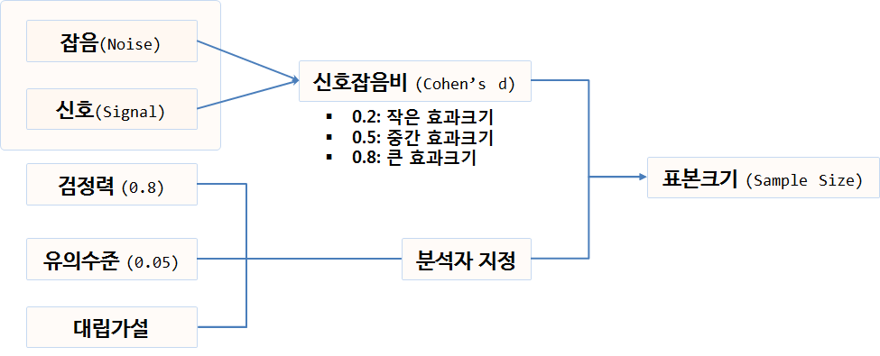

신호와 잡음비가 큰 경우 적은 표본이 필요하고, 신호와 잡음비가 작은 경우 더 많은 표본이 필요하다. 0.2는 작은 효과크기, 0.5는 중간 효과크기, 0.8은 큰 효과크기로 통상 정의한다. 그리고 1종, 2종에 대한 오류에 대해 $\alpha$ 유의수준과 검정력을 정의하고 대립가설 방향에 대해 지정하면 `pwr` 팩키지 표본크기 함수룰 통해 최소 필요한 표본크기를 추출할 수 있다.

### 2.1. 웹사이트 개선 전후 효과를 탐지하는 표본크기

웹사이트 개선 전후 효과를 탐지하는데 필요한 표본크기 정보를 파악해야 된다. 즉, 현재 웹사이트 전환율은 1.5% 인데, 새로운 웹사이트를 적용할 경우 웹사이트 개편에 대한 효과크기를 탐지하는데 필요한 최소한의 표본은 얼마나 될까?

```r
# 0. 환경설정 ----------------------------------
# library(tidyverse)
# library(ggplot2)
# library(ggthemes)
# library(extrafont)
# library(pwr)
# library(prevalence) # https://gist.github.com/casallas/8411082
# loadfonts()

# 1. 표본크기 ----------------------------------
## 1.1. 현재 웹사이트 전환율(Conversion Rate)
web_a <- 15
web_n_a <- 1000
(web_p_a <- web_a / web_n_a)
```

```
[1] 0.015
```

```r
## 1.2. 효과크기를 탐지하는데 필요한 표본크기
pwr.2p2n.test(h=0.2, n1=1000, sig.level=0.05, power=0.8, alternative="two.sided")
```

```
     difference of proportion power calculation for binomial distribution (arcsine transformation)

              h = 0.2
             n1 = 1000
             n2 = 244.1239
      sig.level = 0.05
          power = 0.8
    alternative = two.sided

NOTE: different sample sizes
```

`pwr.2p2n.test(h=0.2, n1=1000, sig.level=0.05, power=0.8)` 명령어를 통해 유의수준 5%, 검정력 80%, n1 표본 1,000개인 경우 효과크기를 0.2로 설정하여 양측검정을 하게 되면 244.1239 즉, 245명의 방문자가 최소 필요한 것이 확인된다.

### 2.2. 웹사이트 반응률 1% 높이는 효과를 파악하는데 필요한 표본크기

전화율 1%를 높이는데 필요한 표본크기는 얼마나 될까? 이것도 흥미있는 질문이다.

```r
## 1.3. 1% 전환율을 높이는데 필요한 표본크기(알파=0.05, 검정력=0.8)
power.prop.test(p1=web_p_a, p2=web_p_a+0.01, sig.level=0.05, power=0.8)
```

```
     Two-sample comparison of proportions power calculation

              n = 3075.582
             p1 = 0.015
             p2 = 0.025
      sig.level = 0.05
          power = 0.8
    alternative = two.sided

NOTE: n is number in *each* group
```

유의수준 5%, 검정력 80%, 현 웹사이트 전환율과 신규 웹사이트 전환율을 입력하여 필요한 유효표본수를 검출한다. 3075.582, 즉 3,076 방문자가 필요하다.

### 2.3. 캠페인 효과

웹사이트 A가 현재 붉은 색으로 개발되어 있는데, 고객설문조사결과 파란색으로 디자인을 바꿔 개발할 경우 더 좋은 효과가 예상된다고 한다. 그래서 개발팀에서 1달간의 크런치 모드를 진행하여 초단기 웹사이트 B를 개발했다. 그런데 이러한 웹사이트 변경이 정말 효과가 있는 것인지, 아니면 우연에 의한 것이지 확인하고자 한다.

이런 경우 사용하는 함수가 `prop.test`가 된다. 기존 웹사이트 A는 방문자가 1,000 명당 32명의 전환율을 보인 반면, 새로 개발한 웹사이트 B는 1,000명당 54명 전환율을 보인다. `prop.test`결과 p-값이 `0.02062`으로 나와 0.05 보다 작기 때문에 웹사이트 A나 웹사이트 B나 동일하다는 귀무가설을 기각하게 되어 효과가 있는 것으로 결정한다.

신뢰구간도 다음 공식에 기초하여 계산하면 되지만, `prevalence` 팩키지에 신뢰구간을 구하는 다양한 방법이 구현되어 있어 이를 활용한다.

$$\hat p \pm z \sqrt{\frac{1}{n}\hat p \left(1 - \hat p \right)}$$

마지막으로 웹사이트 A,B에 대한 전환율을 시각적으로 확인한다.

```r
# 2. 실제효과 검정 ----------------------------------
web_a <- 32
web_n_a <- 1000
(web_p_a <- web_a / web_n_a)
```

```
[1] 0.032
```

```r
web_b <- 54
web_n_b <- 1000
(web_p_b <- web_b / web_n_b)
```

```
[1] 0.054
```

```r
prop.test(c(web_a, web_b), c(web_n_a,web_n_b))
```

```
    2-sample test for equality of proportions with continuity
    correction

data:  c(web_a, web_b) out of c(web_n_a, web_n_b)
X-squared = 5.3583, df = 1, p-value = 0.02062
alternative hypothesis: two.sided
95 percent confidence interval:
 -0.040754721 -0.003245279
sample estimates:
prop 1 prop 2
 0.032  0.054
```

```r
## 2.1. 신뢰구간 ----------------------------------

prevalence::propCI(x=web_a, n=web_n_a, level = 0.95)
```

```
   x    n     p        method level      lower      upper
1 32 1000 0.032 agresti.coull  0.95 0.02261326 0.04496859
2 32 1000 0.032         exact  0.95 0.02198885 0.04487590
3 32 1000 0.032      jeffreys  0.95 0.02240527 0.04429584
4 32 1000 0.032          wald  0.95 0.02109161 0.04290839
5 32 1000 0.032        wilson  0.95 0.02275711 0.04482474
```

```r
prevalence::propCI(x=web_b, n=web_n_b, level = 0.95)
```

```
   x    n     p        method level      lower      upper
1 54 1000 0.054 agresti.coull  0.95 0.04151868 0.06989479
2 54 1000 0.054         exact  0.95 0.04082335 0.06987401
3 54 1000 0.054      jeffreys  0.95 0.04126091 0.06931476
4 54 1000 0.054          wald  0.95 0.03999154 0.06800846
5 54 1000 0.054        wilson  0.95 0.04162131 0.06979215
```

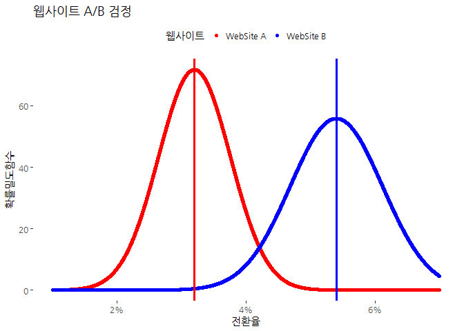

```r
## 2.3. 신뢰구간 시각화  ----------------------------------

x_a  <- seq(from=0.01, to=0.07, by=0.00001)
y_a  <- dnorm(x_a, mean = web_p_a, sd = sqrt((web_p_a * (1-web_p_a))/web_n_a))

x_b  <- seq(from=0.01, to=0.07, by=0.00001)
y_b  <- dnorm(x_b, mean = web_p_b, sd = sqrt((web_p_b * (1-web_p_b))/web_n_b))

ab_df  <- tibble(web_x_a=x_a, web_y_a=y_a, web_x_b=x_b, web_y_b=y_b)

options(repr.plot.width=7, repr.plot.height=3)

website_cols  <- c("WebSite A"="red","WebSite B"="blue")

ggplot(data = ab_df) +
  labs(title="웹사이트 A/B 검정",
        x="전환율", y="확률밀도함수") +
  theme_tufte(base_family = "NanumGothic") +
  scale_x_continuous(labels = scales::percent) +
  geom_point(aes(x=x_a, y=y_a, colour="WebSite A")) +
  geom_point(aes(x=x_b, y=y_b, colour="WebSite B")) +
  scale_colour_manual(name="웹사이트", values=website_cols) +
  geom_vline(aes(xintercept=0.032), colour = "red", size=1.1) +
  geom_vline(aes(xintercept=0.054), colour = "blue", size=1.1) +
  theme(legend.position = "top")
```

### A/B 검정과 $t-$검정 차이

> A/B 검정은 독립된 두 표본을 비교하는 실험을 설계, 수행, 분석하는 전체적인 틀(프레임워크인)인 반면, $t-$검정은 동일한 개념에 대한 통계적인 절차로 볼 수 있는데, 1908년 윌리엄 고셋이 기네스 맥주회사에서 맥주 품질검정을 위해 고안한 통계적 방법으로 $t-$검정으로 알려져 있다. [^6]

## 3. 캠페인 효과가 분수가 아닌 경우

평균 주문금액, 평균 웹페이지 채류시간처럼 정규분포를 따르는 분수가 아닌 값을 비교한느데 사용되는 되는 것이 독립 이표본 $t-$검정으로, 웰치 $t-$검정을 사용하는데 이유는 두 집단 모두에 대해 표본크기가 다르고, 등분산을 갖지 않더라고 적용이 가능하다. 데이터의 정규성 검정을 사전에 하고 필요한 경우 박스-콕스 변환을 수행한 후에 검정을 수행한다.

```r
# 1. 정규분포 ----------------------------------
pwr.t2n.test(n1=10000, d=0.5, sig.level=0.05, power=0.90)
```

```
     t test power calculation

             n1 = 10000
             n2 = 42.21518
              d = 0.5
      sig.level = 0.05
          power = 0.9
    alternative = two.sided
```

```r
## 1.1. 캠페인 효과 검정 -----------------------

group1 <- c(64.2,28.4,85.3,83.1,13.4,56.8,44.2,90)
group2 <- c(45, 29.5,32.3, 49.3,18.3, 34.2,43.9, 13.8,27.4, 43.4)

t.test(group1, group2)
```

```
    Welch Two Sample t-test

data:  group1 and group2
t = 2.3103, df = 9.0005, p-value = 0.04621
alternative hypothesis: true difference in means is not equal to 0
95 percent confidence interval:
  0.5097856 48.4202144
sample estimates:
mean of x mean of y
   58.175    33.710
```

## 4. 웹사이트 선호도 고객만족도 조사

데이터는 [Practical Statistics for HCI](http://depts.washington.edu/aimgroup/proj/ps4hci/) 사이트에 공개된 SPSS 파일을 R로 불러와서 실험 검증에 사용한다. 웹선호도에 대한 코딩이 `1`, `2`로 되어 있다. 이를 `웹사이트 A`, `웹사이트 B` 로 요인 수준을 사람이 이해하기 쉽게 바꾼다.

### 4.1. 두가지 웹사이트 선호도

```r
# 2. 선호도 검정 ----------------------------------
## 2.1. 웹사이트 A, B
tc <- textConnection("subject, preference
                      1    ,      1
                      2    ,      2
                      3    ,      2
                      4    ,      1
                      5    ,      1
                      6    ,      1
                      7    ,      2
                      8    ,      2
                      9    ,      1
                      10   ,       1
                      11   ,       1
                      12   ,       1
                      13   ,       1
                      14   ,       2
                      15   ,       2
                      16   ,       1
                      17   ,       1
                      18   ,       2
                      19   ,       1
                      20   ,       1
                      21   ,       2
                      22   ,       2
                      23   ,       1
                      24   ,       1
                      25   ,       1
                      26   ,       1
                      27   ,       1
                      28   ,       1
                      29   ,       1
                      30   ,       1")

pref_df <- read.csv(tc, header = TRUE)
pref_df <- pref_df %>% mutate(preference = factor(preference,
                                        levels=c(1,2),
                                        labels=c("웹사이트 A", "웹사이트 B")))

(website_prefs <- xtabs( ~ preference, data=pref_df))
```

```
preference
웹사이트 A 웹사이트 B
        21          9
```

```r
chisq.test(website_prefs)
```

```
    Chi-squared test for given probabilities

data:  website_prefs
X-squared = 4.8, df = 1, p-value = 0.02846
```

$p-$값 0.05를 기준으로 본다면, 웹사이트 A와 B 선호도에 유의성이 있다는 결론에 도달하게 된다.

```r
binom.test(website_prefs)
```

```
    Exact binomial test

data:  website_prefs
number of successes = 21, number of trials = 30, p-value = 0.04277
alternative hypothesis: true probability of success is not equal to 0.5
95 percent confidence interval:
 0.5060410 0.8526548
sample estimates:
probability of success
                   0.7
```

$\chi^2$ 검정은 표본수가 많아지게 되면 정확도가 높아지는 근사검정이지만, 정확 이항 검정(Exact Binomial Test)은 컴퓨팅 계산에 부담이 되지만, 근사 검정이 아니고 정확 검정이다. 귀무가설 웹사이트 A와 B의 선호도가 같다는 95% 신뢰구간에 0.5가 포함되지 않고 있다.

### 4.2. 세가지 웹사이트 선호도

웹사이트가 A,B 두가지 아니고 3개 이상인 경우 A,B,C 웹사이트 간에 선호도 차이가 있는지 검정한다.

웹선호도에 대한 코딩이 `1`, `2`, `3`으로 되어 있다. 이를 `웹사이트 A`, `웹사이트 B`, `웹사이트 C`로 코딩을 바꾼다.

```r
tcon <- textConnection("subject, preference
1   ,       3
2   ,       3
3   ,       3
4   ,       1
5   ,       1
6   ,       3
7   ,       3
8   ,       2
9   ,       1
10  ,        3
11  ,        1
12  ,        1
13  ,        3
14  ,        3
15  ,        2
16  ,        3
17  ,        1
18  ,        3
19  ,        1
20  ,        1
21  ,        2
22  ,        2
23  ,        3
24  ,        1
25  ,        1
26  ,        1
27  ,        3
28  ,        1
29  ,        1
30  ,        3")

pref_three_df <- read.csv(tcon, header = TRUE)
pref_three_df <- pref_three_df %>% mutate(preference = factor(preference,
                                                  levels=c(1,2,3),
                                                  labels=c("웹사이트 A", "웹사이트 B", "웹사이트 C")))

(websites_prefs <- xtabs( ~ preference, data=pref_three_df))
```

```
preference
웹사이트 A 웹사이트 B 웹사이트 C
        13          4         13
```

```r
chisq.test(websites_prefs)
```

```
    Chi-squared test for given probabilities

data:  websites_prefs
X-squared = 5.4, df = 2, p-value = 0.06721
```

$p-$값 0.05를 기준으로 본다면, 웹사이트 A, B, C 선호도에 유의성이 없다는 결론에 도달할 수 있지만, 0.05에 가깝기 때문에 유보한다.

```r
library(XNomial)
xmulti(websites_prefs, c(1/3, 1/3, 1/3), statName = "Prob")
```

```
P value (Prob) = 0.05117
```

```r
# 다중 비교
aa <- binom.test(sum(pref_three_df$preference=='웹사이트 A'), nrow(pref_three_df), p=1/3)
bb <- binom.test(sum(pref_three_df$preference=='웹사이트 B'), nrow(pref_three_df), p=1/3)
cc <- binom.test(sum(pref_three_df$preference=='웹사이트 C'), nrow(pref_three_df), p=1/3)
p.adjust(c(aa$p.value, bb$p.value, cc$p.value), method="holm")
```

```
[1] 0.4996989 0.0583577 0.4996989
```

다항분포 검정을 통한 정확 다항검정에서는 0.05에 더욱 가까운 $p-$ 값이 검출되었다.

다중비교는 세가지 웹사이트 간에 차이가 있다는 것은 이해가 되나 어느 것에서 차이가 나는지 검출할 때 사용한다.

[^1]: [A/B testing](https://en.wikipedia.org/wiki/A/B_testing)
[^2]: [http://www.statmethods.net/, Power Analysis](http://www.statmethods.net/stats/power.html)
[^3]: [A/B Tests in Marketing – Sample Size and Significance using R](http://www.marketingdistillery.com/2014/08/03/ab-tests-in-marketing-sample-size-and-significance-using-r/)
[^4]: [A/B Testing, from scratch](http://www.alfredo.motta.name/ab-testing-from-scratch/)
[^5]: [3Rs- Reduction.co.uk, Power and Sample Size](http://www.3rs-reduction.co.uk/html/6__power_and_sample_size.html)
[^6]: What is the difference between A/B testing and a t-test?](https://www.quora.com/What-is-the-difference-between-A-B-testing-and-a-t-test)